# Notes L

[figure not shown]

```r
ggplot() +
  # plot the slopes of all the replicates
  geom_smooth(
    data = kangaroo_rats_many, aes(x = hfl, y = wgt, group = replicate),
    method = "lm", se = FALSE, fullrange = TRUE,
    color = "grey", linewidth = 0.1
  ) +
  # plot the slope of all kangaroo rats in Portal, AZ
  geom_smooth(
    data = kangaroo_rats, aes(x = hfl, y = wgt), method = "lm", se = FALSE,
    fullrange = TRUE, color = "blue"
  ) +
  ggtitle("Repeated Samples of size n=500") +
  theme_minimal()
```

- You might notice in the above figure that the $\hat{y}$ values given by the lines are much more consistent in the middle of the dataset than at the ends. The reason is that the data itself anchors the lines in such a way that the line must pass through the center of the data cloud.

[figure not shown]

```r
kangaroo_rats_many_lm <- kangaroo_rats_many %>%
  group_by(replicate) %>%
  do(tidy(lm(wgt ~ hfl, data = .))) %>%
  filter(term == "hfl")

ggplot(kangaroo_rats_many_lm, aes(x = estimate)) +
  geom_histogram(binwidth=0.5) +
  labs(
    x = "Slope estimate",
    y = "Count",
    title = "Banner-tailed Kangaroo Rats",
    subtitle = "Many random samples of 500 rats"
  ) +
  theme_minimal()
```

Understanding how much the slope varies from sample to sample helps us better understand a range of likely values for the true slope!

(Take a stats class to learn more!)

# Assumptions, Residuals, and Residual Plots

There are some!

## Interpolation vs. Extrapolation

**Interpolation** is a method of estimating a hypothetical value that exists within a data set.

**Extrapolation** is a method of estimation for hypothetical values that fall outside a data set.

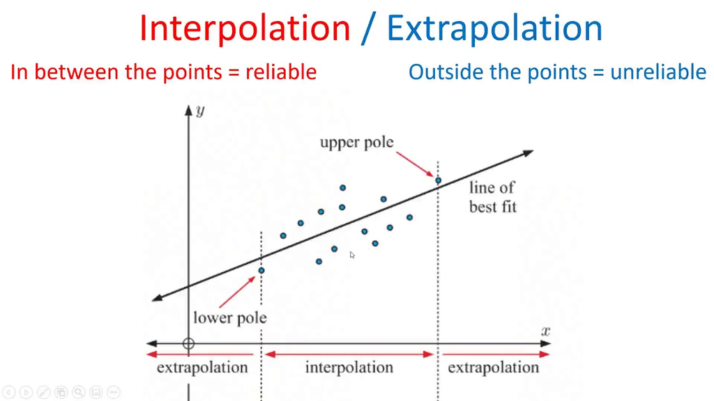